# Ex31 area glm

PIE2

Tardor 2019-2020

#### Continuació de l’exercici 26):

#### Tenim els resultats de mesurar l’àrea que cobreixen plantes entapissant a talussos de carreteres. S’han estudiat dues especies E1 i E2 (factor ESPECIE) i haver posat, o no, compost al talús (factor COMPOST). Les dades experimentals són al fitxer “area.csv”.

*llegir dades, paquests, descriptiva…*

```r
#setwd("...")
library(emmeans)
library(car)
dd<-read.csv2("../data/area.csv")
library(RcmdrMisc)
library(tables)
cv<-function(x) {sd(x)/mean(x)}
print(tabular(AREA*ESPECIE*COMPOST~((Dades=1)+(Mitjana=mean)+(Desv.tipus=sd)+(Coef.var.=cv)),dd),justification="r")
```

```
##
##       ESPECIE COMPOST Dades Mitjana Desv.tipus Coef.var.
##  AREA      E1      no     6   46.15      11.46    0.2484
##                    sí     6  347.74      77.38    0.2225
##            E2      no     6  126.07      29.19    0.2315
##                    sí     6  459.68     115.19    0.2506
```

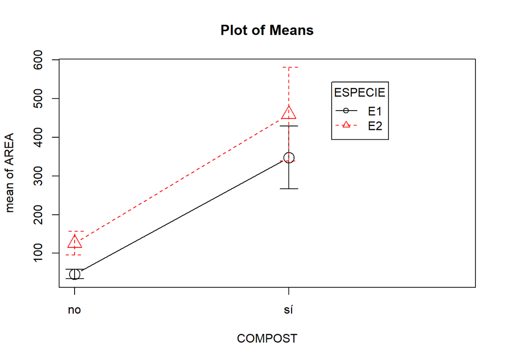

```r
#with(dd,plotMeans(AREA,ESPECIE,COMPOST,error.bars="conf.int",level=0.95))
with(dd,plotMeans(AREA,COMPOST,ESPECIE,error.bars="conf.int",level=0.95))
```

#### Suposant ara, que la variable aleatòria AREA té distribució Gamma, i utilitzant $\alpha = 0.05$:

**Plantegeu el mlg de la variable AREA respecte els factors ESPECIE i COMPOST sense interacció.**

#### a) Utilitzant la funció link identity:

*Recordeu: en l’exercici 26) vèiem que AREA no té interacció però no compleix la homoscedasticitat, en canvi log(AREA) té interacció però si compleix la homoscedasticitat, en la separació de mitjanes no distingiem E1-Sí de E2-Sí*

**• Ajusteu el model.**

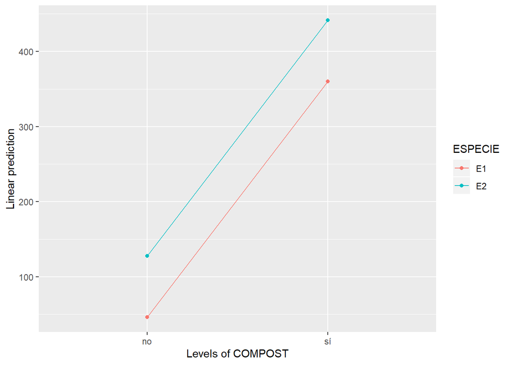

```r
mg<-glm(AREA~ESPECIE+COMPOST,family=Gamma(link=identity),dd)
mg0<-glm(AREA~1,family=Gamma(link=identity),dd)
mgf<-glm(AREA~ESPECIE*COMPOST,family=Gamma(link=identity),dd)
emmip(mg,ESPECIE~COMPOST)
```

```r
summary(mg)
```

```
##
## Call:
## glm(formula = AREA ~ ESPECIE + COMPOST, family = Gamma(link = identity),
##     data = dd)
##
## Deviance Residuals:
##      Min        1Q    Median        3Q       Max
## -0.49156  -0.19497   0.02953   0.14363   0.35144
##
## Coefficients:
##             Estimate Std. Error t value Pr(>|t|)
## (Intercept)    45.95       4.40  10.444 9.01e-10 ***
## ESPECIEE2      81.64      12.67   6.443 2.19e-06 ***
## COMPOSTsí     313.89      27.35  11.478 1.65e-10 ***
## ---
## Signif. codes:  0 '***' 0.001 '**' 0.01 '*' 0.05 '.' 0.1 ' ' 1
##
## (Dispersion parameter for Gamma family taken to be 0.05534811)
##
##     Null deviance: 17.4558  on 23  degrees of freedom
## Residual deviance:  1.2386  on 21  degrees of freedom
## AIC: 251.77
##
## Number of Fisher Scoring iterations: 4
```

**• Contrasteu el test anova. Què ens diu el test?**

```r
#Omnibus
anova(mg0,mg,test="F")
```

```
## Analysis of Deviance Table
##
## Model 1: AREA ~ 1
## Model 2: AREA ~ ESPECIE + COMPOST
##   Resid. Df Resid. Dev Df Deviance     F    Pr(>F)
## 1        23    17.4558
## 2        21     1.2386  2   16.217 146.5 4.629e-13 ***
## ---
## Signif. codes:  0 '***' 0.001 '**' 0.01 '*' 0.05 '.' 0.1 ' ' 1
```

```r
#Anova
Anova(mg,test.statistic = "F")
```

```
## Analysis of Deviance Table (Type II tests)
##
## Response: AREA
## Error estimate based on Pearson residuals
##
##            Sum Sq Df F value    Pr(>F)
## ESPECIE    3.1257  1  56.474 2.212e-07 ***
## COMPOST   15.2785  1 276.044 1.475e-13 ***
## Residuals  1.1623 21
## ---
## Signif. codes:  0 '***' 0.001 '**' 0.01 '*' 0.05 '.' 0.1 ' ' 1
```

**• Contrasteu el test adequat per comprovar que en el model no era necessària la interacció dels dos factors.**

```r
anova(mg,mgf,test="F")
```

```
## Analysis of Deviance Table
##
## Model 1: AREA ~ ESPECIE + COMPOST
## Model 2: AREA ~ ESPECIE * COMPOST
##   Resid. Df Resid. Dev Df Deviance      F Pr(>F)
## 1        21     1.2386
## 2        20     1.2208  1 0.017832 0.3134 0.5818
```

```r
Anova(mgf,test.statistic = "F")
```

```
## Analysis of Deviance Table (Type II tests)
##
## Response: AREA
## Error estimate based on Pearson residuals
##
##                  Sum Sq Df  F value    Pr(>F)
## ESPECIE          3.1257  1  54.9338 3.715e-07 ***
## COMPOST         15.2785  1 268.5146 4.664e-13 ***
## ESPECIE:COMPOST  0.0178  1   0.3134    0.5818
## Residuals        1.1380 20
## ---
## Signif. codes:  0 '***' 0.001 '**' 0.01 '*' 0.05 '.' 0.1 ' ' 1
```

**• Feu les comparacions múltiples. Què ens diuen?**

```r
(emg<-emmeans(mg,~ESPECIE+COMPOST))
```

```
##  ESPECIE COMPOST emmean   SE  df asymp.LCL asymp.UCL
##  E1      no        45.9  4.4 Inf      37.3      54.6
##  E2      no       127.6 12.0 Inf     104.1     151.0
##  E1      sí       359.8 27.3 Inf     306.4     413.3
##  E2      sí       441.5 27.8 Inf     386.9     496.1
##
## Confidence level used: 0.95
```

```r
CLD(emg)
```

```
##  ESPECIE COMPOST emmean   SE  df asymp.LCL asymp.UCL .group
##  E1      no        45.9  4.4 Inf      37.3      54.6  1
##  E2      no       127.6 12.0 Inf     104.1     151.0   2
##  E1      sí       359.8 27.3 Inf     306.4     413.3    3
##  E2      sí       441.5 27.8 Inf     386.9     496.1     4
##
## Confidence level used: 0.95
## P value adjustment: tukey method for comparing a family of 4 estimates
## significance level used: alpha = 0.05
```

```r
CLD(emmeans(mg,~ESPECIE|COMPOST))
```

```
## COMPOST = no:
##  ESPECIE emmean   SE  df asymp.LCL asymp.UCL .group
##  E1        45.9  4.4 Inf      37.3      54.6  1
##  E2       127.6 12.0 Inf     104.1     151.0   2
##
## COMPOST = sí:
##  ESPECIE emmean   SE  df asymp.LCL asymp.UCL .group
##  E1       359.8 27.3 Inf     306.4     413.3  1
##  E2       441.5 27.8 Inf     386.9     496.1   2
##
## Confidence level used: 0.95
## significance level used: alpha = 0.05
```

**• Feu una gràfica de les prediccions amb els intervals de predicció.**

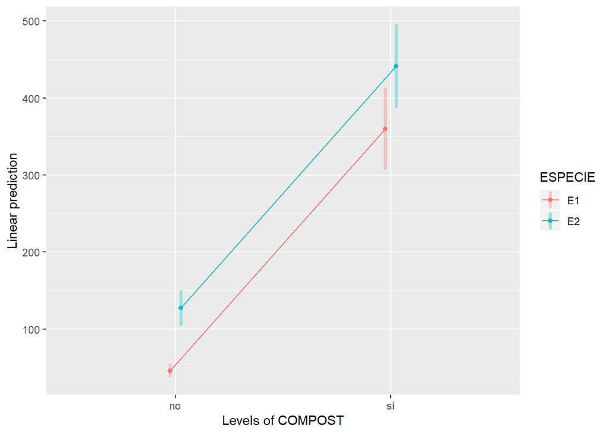

```r
emmip(mg,ESPECIE~COMPOST,PIs=T)
```

**• Mitjançant gràfics de diagnòstic, comproveu si compleixen les hipòtesis dels models lineals generalitzats.**

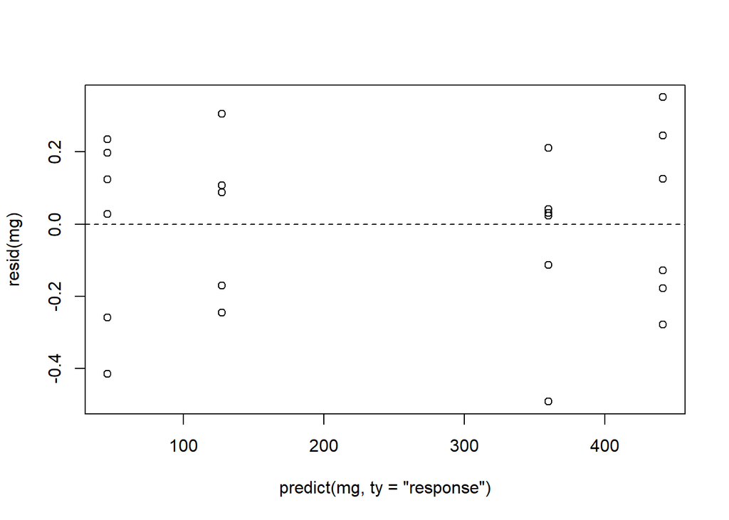

```r
plot(predict(mg,ty="response"),resid(mg))
abline(h=0,lt=2)
```

```r
with(dd,leveneTest(resid(mg),as.factor(paste(ESPECIE,COMPOST))))
```

```
## Levene's Test for Homogeneity of Variance (center = median)
##       Df F value Pr(>F)
## group  3  0.2796 0.8395
##       20
```

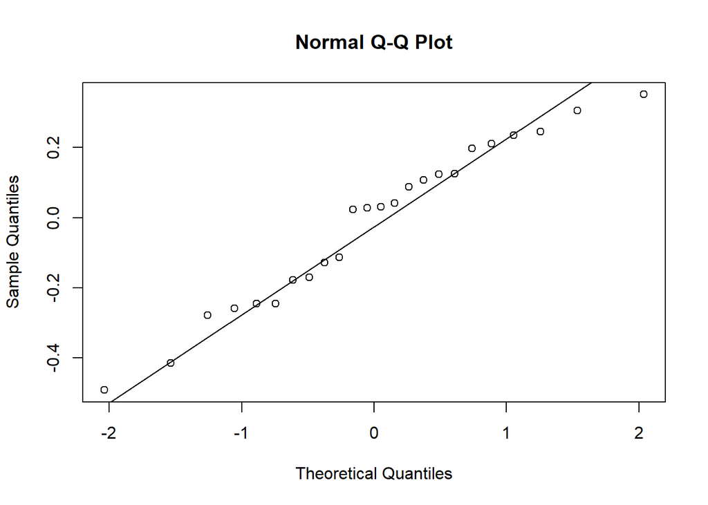

```r
qqnorm(resid(mg))
qqline(resid(mg))
```

#### b) Utilitzant la funció link log, contesteu les preguntes de l’apartat a), amb la diferència que en aquest cas potser sí que fa falta la interacció.

**• Ajusteu el model.**

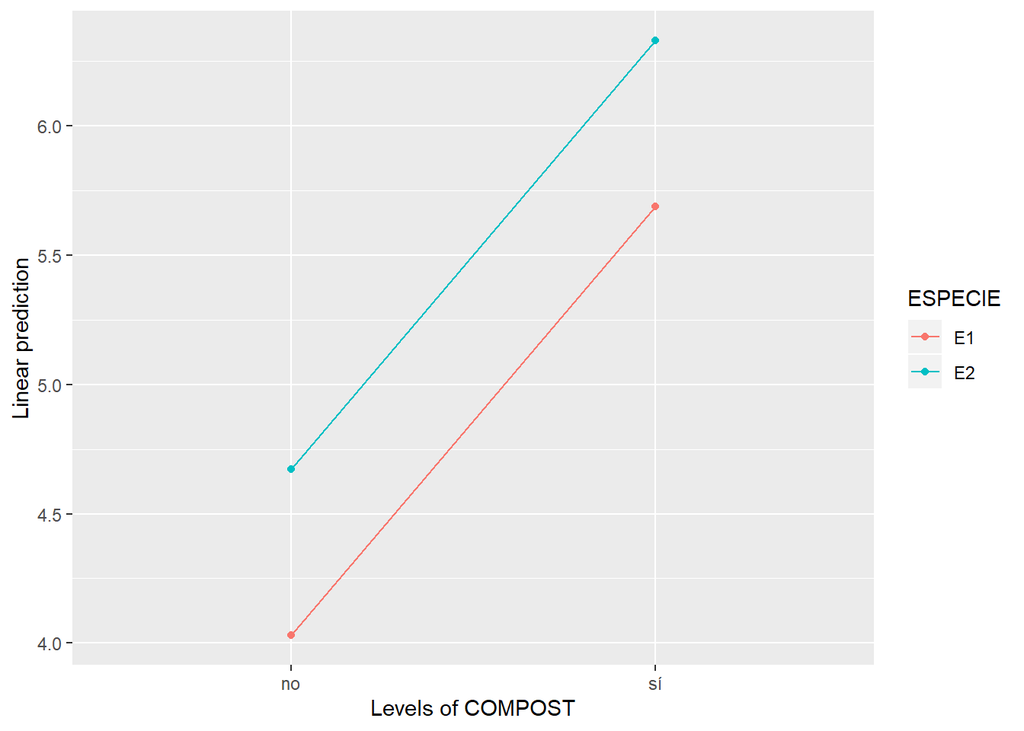

```r
mgl<-glm(AREA~ESPECIE+COMPOST,family=Gamma(link=log),dd)
mgl0<-glm(AREA~1,family=Gamma(link=log),dd)
mglf<-glm(AREA~ESPECIE*COMPOST,family=Gamma(link=log),dd)
emmip(mgl,ESPECIE~COMPOST)
```

```r
summary(mgl)
```

```
##
## Call:
## glm(formula = AREA ~ ESPECIE + COMPOST, family = Gamma(link = log),
##     data = dd)
##
## Deviance Residuals:
##      Min        1Q    Median        3Q       Max
## -0.58423  -0.20680  -0.00641   0.23300   0.50741
##
## Coefficients:
##             Estimate Std. Error t value Pr(>|t|)
## (Intercept)   4.0297     0.1066  37.795  < 2e-16 ***
## ESPECIEE2     0.6421     0.1231   5.215 3.61e-05 ***
## COMPOSTsí     1.6567     0.1231  13.456 8.57e-12 ***
## ---
## Signif. codes:  0 '***' 0.001 '**' 0.01 '*' 0.05 '.' 0.1 ' ' 1
##
## (Dispersion parameter for Gamma family taken to be 0.09094344)
##
##     Null deviance: 17.456  on 23  degrees of freedom
## Residual deviance:  2.007  on 21  degrees of freedom
## AIC: 263.48
##
## Number of Fisher Scoring iterations: 5
```

**• Contrasteu el test anova. Què ens diu el test?**

```r
#Omnibus
anova(mgl0,mgl,test="F")
```

```
## Analysis of Deviance Table
##
## Model 1: AREA ~ 1
## Model 2: AREA ~ ESPECIE + COMPOST
##   Resid. Df Resid. Dev Df Deviance      F   Pr(>F)
## 1        23     17.456
## 2        21      2.007  2   15.449 84.936 8.62e-11 ***
## ---
## Signif. codes:  0 '***' 0.001 '**' 0.01 '*' 0.05 '.' 0.1 ' ' 1
```

```r
#Anova
Anova(mgl,test.statistic = "F")
```

```
## Analysis of Deviance Table (Type II tests)
##
## Response: AREA
## Error estimate based on Pearson residuals
##
##            Sum Sq Df F value    Pr(>F)
## ESPECIE    2.3574  1  25.921 4.833e-05 ***
## COMPOST   14.5101  1 159.551 2.812e-11 ***
## Residuals  1.9098 21
## ---
## Signif. codes:  0 '***' 0.001 '**' 0.01 '*' 0.05 '.' 0.1 ' ' 1
```

**• Contrasteu el test adequat per comprovar que en el model no era necessària la interacció dels dos factors.**

```r
anova(mgl,mglf,test="F")
```

```
## Analysis of Deviance Table
##
## Model 1: AREA ~ ESPECIE + COMPOST
## Model 2: AREA ~ ESPECIE * COMPOST
##   Resid. Df Resid. Dev Df Deviance      F   Pr(>F)
## 1        21     2.0070
## 2        20     1.2208  1  0.78621 13.817 0.001362 **
## ---
## Signif. codes:  0 '***' 0.001 '**' 0.01 '*' 0.05 '.' 0.1 ' ' 1
```

```r
Anova(mglf,test.statistic = "F")
```

```
## Analysis of Deviance Table (Type II tests)
##
## Response: AREA
## Error estimate based on Pearson residuals
##
##                  Sum Sq Df F value    Pr(>F)
## ESPECIE          2.3574  1  41.430 2.812e-06 ***
## COMPOST         14.5101  1 255.011 7.545e-13 ***
## ESPECIE:COMPOST  0.7862  1  13.817  0.001362 **
## Residuals        1.1380 20
## ---
## Signif. codes:  0 '***' 0.001 '**' 0.01 '*' 0.05 '.' 0.1 ' ' 1
```

**• Feu les comparacions múltiples. Què ens diuen?**

*Amb el model additiu veiem que les estimacións són diferents del model amb link=identity*

```r
emg
```

```
##  ESPECIE COMPOST emmean   SE  df asymp.LCL asymp.UCL
##  E1      no        45.9  4.4 Inf      37.3      54.6
##  E2      no       127.6 12.0 Inf     104.1     151.0
##  E1      sí       359.8 27.3 Inf     306.4     413.3
##  E2      sí       441.5 27.8 Inf     386.9     496.1
##
## Confidence level used: 0.95
```

```r
(emgl<-emmeans(mgl,~ESPECIE+COMPOST,ty="response"))
```

```
##  ESPECIE COMPOST response   SE  df asymp.LCL asymp.UCL
##  E1      no          56.2  6.0 Inf      45.6      69.3
##  E2      no         106.9 11.4 Inf      86.7     131.7
##  E1      sí         294.8 31.4 Inf     239.2     363.3
##  E2      sí         560.3 59.7 Inf     454.6     690.5
##
## Confidence level used: 0.95
## Intervals are back-transformed from the log scale
```

*Passem al model factorial, ja que fa falta la interacció**

```r
(emglf<-emmeans(mglf,~ESPECIE*COMPOST,ty="response"))
```

```
##  ESPECIE COMPOST response    SE  df asymp.LCL asymp.UCL
##  E1      no          46.1  4.49 Inf      38.1      55.9
##  E2      no         126.1 12.28 Inf     104.2     152.6
##  E1      sí         347.7 33.86 Inf     287.3     420.9
##  E2      sí         459.7 44.77 Inf     379.8     556.4
##
## Confidence level used: 0.95
## Intervals are back-transformed from the log scale
```

```r
CLD(emglf)
```

```
##  ESPECIE COMPOST response    SE  df asymp.LCL asymp.UCL .group
##  E1      no          46.1  4.49 Inf      38.1      55.9  1
##  E2      no         126.1 12.28 Inf     104.2     152.6   2
##  E1      sí         347.7 33.86 Inf     287.3     420.9    3
##  E2      sí         459.7 44.77 Inf     379.8     556.4    3
##
## Confidence level used: 0.95
## Intervals are back-transformed from the log scale
## P value adjustment: tukey method for comparing a family of 4 estimates
## Tests are performed on the log scale
## significance level used: alpha = 0.05
```

*Nota: No distingeix E1-Sí de E2-Sí*

**• Feu una gràfica de les prediccions amb els intervals de predicció.**

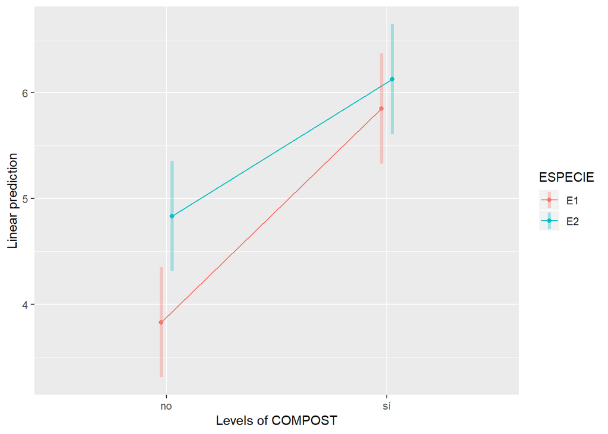

```r
emmip(mglf,ESPECIE~COMPOST,PIs=T)
```

**• Mitjançant gràfics de diagnòstic, comproveu si compleixen les hipòtesis dels models lineals generalitzats.**

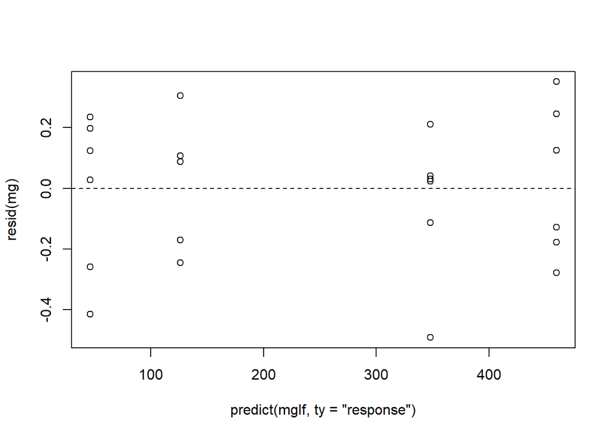

```r
plot(predict(mglf,ty="response"),resid(mg))
abline(h=0,lt=2)
```

```r
with(dd,leveneTest(resid(mglf),as.factor(paste(ESPECIE,COMPOST))))
```

```
## Levene's Test for Homogeneity of Variance (center = median)
##       Df F value Pr(>F)
## group  3  0.2496 0.8606
##       20
```

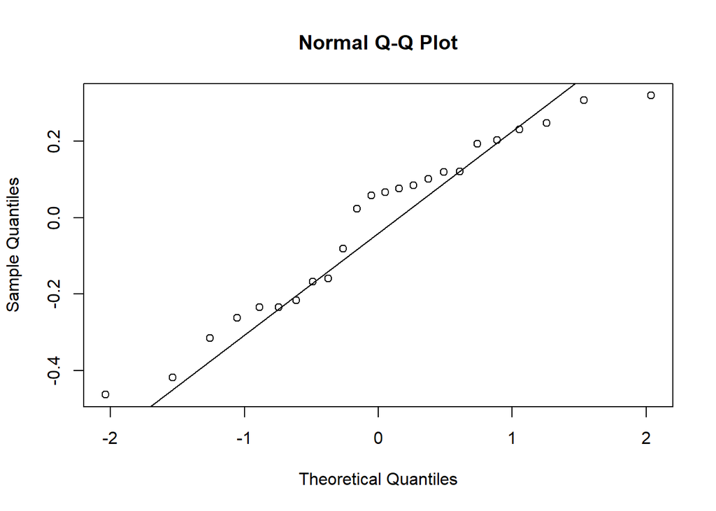

```r
qqnorm(resid(mglf))
qqline(resid(mglf))
```

#### c) Si féssim el mlg amb interacció, comproveu que obtindríem les mateixes prediccions i comparacions múltiples, tant si utilitzem el link identity com si utilitzem el log, i que seria diferent tot el que fa referència als predictors lineals

```r
(emgf<-emmeans(mgf,~ESPECIE*COMPOST,ty="response"))
```

```
##  ESPECIE COMPOST emmean    SE  df asymp.LCL asymp.UCL
##  E1      no        46.1  4.49 Inf      37.3        55
##  E2      no       126.1 12.28 Inf     102.0       150
##  E1      sí       347.7 33.86 Inf     281.4       414
##  E2      sí       459.7 44.77 Inf     371.9       547
##
## Confidence level used: 0.95
```

```r
emglf
```

```
##  ESPECIE COMPOST response    SE  df asymp.LCL asymp.UCL
##  E1      no          46.1  4.49 Inf      38.1      55.9
##  E2      no         126.1 12.28 Inf     104.2     152.6
##  E1      sí         347.7 33.86 Inf     287.3     420.9
##  E2      sí         459.7 44.77 Inf     379.8     556.4
##
## Confidence level used: 0.95
## Intervals are back-transformed from the log scale
```

```r
(emgf<-emmeans(mglf,~ESPECIE*COMPOST))
```

```
##  ESPECIE COMPOST emmean     SE  df asymp.LCL asymp.UCL
##  E1      no        3.83 0.0974 Inf      3.64      4.02
##  E2      no        4.84 0.0974 Inf      4.65      5.03
##  E1      sí        5.85 0.0974 Inf      5.66      6.04
##  E2      sí        6.13 0.0974 Inf      5.94      6.32
##
## Results are given on the log (not the response) scale.
## Confidence level used: 0.95
```

```r
summary(mglf)
```

```
##
## Call:
## glm(formula = AREA ~ ESPECIE * COMPOST, family = Gamma(link = log),
##     data = dd)
##
## Deviance Residuals:
##      Min        1Q    Median        3Q       Max
## -0.46258  -0.22056   0.06189   0.13872   0.31887
##
## Coefficients:
##                     Estimate Std. Error t value Pr(>|t|)
## (Intercept)          3.83182    0.09738  39.348  < 2e-16 ***
## ESPECIEE2            1.00503    0.13772   7.298 4.68e-07 ***
## COMPOSTsí            2.01965    0.13772  14.665 3.65e-12 ***
## ESPECIEE2:COMPOSTsí -0.72595    0.19476  -3.727  0.00133 **
## ---
## Signif. codes:  0 '***' 0.001 '**' 0.01 '*' 0.05 '.' 0.1 ' ' 1
##
## (Dispersion parameter for Gamma family taken to be 0.05690005)
##
##     Null deviance: 17.4558  on 23  degrees of freedom
## Residual deviance:  1.2208  on 20  degrees of freedom
## AIC: 253.41
##
## Number of Fisher Scoring iterations: 4
```

```r
summary(mgl)
```

```
##
## Call:
## glm(formula = AREA ~ ESPECIE + COMPOST, family = Gamma(link = log),
##     data = dd)
##
## Deviance Residuals:
##      Min        1Q    Median        3Q       Max
## -0.58423  -0.20680  -0.00641   0.23300   0.50741
##
## Coefficients:
##             Estimate Std. Error t value Pr(>|t|)
## (Intercept)   4.0297     0.1066  37.795  < 2e-16 ***
## ESPECIEE2     0.6421     0.1231   5.215 3.61e-05 ***
## COMPOSTsí     1.6567     0.1231  13.456 8.57e-12 ***
## ---
## Signif. codes:  0 '***' 0.001 '**' 0.01 '*' 0.05 '.' 0.1 ' ' 1
##
## (Dispersion parameter for Gamma family taken to be 0.09094344)
##
##     Null deviance: 17.456  on 23  degrees of freedom
## Residual deviance:  2.007  on 21  degrees of freedom
## AIC: 263.48
##
## Number of Fisher Scoring iterations: 5
```